# ISRaD user manual

Alison Hoyt

8/15/2019

### Helpful packages for this tutorial:

```r
#Packages to install (you only need to do this once)
#For data analysis:
install.packages("tidyverse") #includes dplyr, ggplot2
install.packages("maps")
install.packages("ggmap")

#For loading the ISRaD package below:
install.packages("devtools")
install.packages("rcrossref")

#Load these packages (you need to do this every time you restart R)
library(tidyverse)
library(maps)
library(ggmap)
library(devtools)
library(rcrossref)
```

## Working with the database in R

The ISRaD database includes:  
1) **ISRaD_data**: The complete collection of data, reported from publications, compiled in one place  
2) **ISRaD_extra**: An augmented dataset, with useful global variables and radiocarbon calculations completed for you  
3) **Tools**: Options to compile your own dataset to compare to ISRaD, and functions to work with the data

## Two options to download ISRaD data:

#### Manually Download & load into R:

1. Download from www.soilradiocarbon.org following the blue “Download” link [on this page](https://international-soil-radiocarbon-database.github.io/ISRaD/database/).
2. Unzip the files
3. Load the .rda files into R. Specify the folder.

```r
load("C:/Users/YourPathHere/ISRaD_data_v1-2019-08-13.rda") #Loads ISRaD_data
load("C:/Users/YourPathHere/ISRaD_data_v1-2019-08-13.rda") #Loads ISRaD_extra
```

#### Install the data through the ISRaD R package:

1. Install and load the ‘devtools’ and ‘rcrossref’ packages
2. Install the ISRaD package from Github
3. Use the ‘get_data’ function to download the latest version of the database

```r
# 'devtools' allows you to install the ISRaD package in its "beta"/development form
# 'rcrossref' is used by our QAQC tool, but sometimes ISRaD won't install without it
install.packages("devtools")
library(devtools)
install.packages("rcrossref")
library("rcrossref")
```

```r
# 2) Install package 'ISRaD' from the development branch of our github repository:
devtools::install_github("International-Soil-Radiocarbon-Database/ISRaD/Rpkg", ref="master", force = T)
library(ISRaD) # load the package
```

```r
# 3) Load data using the get_data function:
mydir <- "C:/Users/YourPathHere/"
ISRaD_extra <-ISRaD.getdata(directory = mydir, dataset="full", extra = T, force_download = T)
```

#### Some other useful packages for working with the data:

Tidyverse and dplyr (part of tidyverse) are useful packages for exploration of ISRaD data. This is a [helpful cheatsheet](https://www.rstudio.com/wp-content/uploads/2015/02/data-wrangling-cheatsheet.pdf).

We use packages `dplyr` for filtering data and `ggplot` for plotting. Both packages are included in the `tidyverse` library.

```r
install.packages("tidyverse")
library(tidyverse)

install.packages("ggplot2") #should be included in tidyverse, but you may want to install separately
library(ggplot2)
```

## Structure of ISRaD data

The ISRaD data are formated as a list in an R object called `ISRaD_data`. `ISRaD_data` is a list comprised of 8 data.frames (`metadata`, `site`, `profile`, `flux`, `layer`, `interstitial`, `fraction`, and `incubation`), which correspond to the template data tables. ‘ISRaD_extra’ follows the same structure. Here is a [conceptual overview of the data structure](https://international-soil-radiocarbon-database.github.io/ISRaD/database/).

```r
#Check to make sure the package is loaded by looking for the database object "ISRaD_data"
#View a single table (e.g. Site, Profile, Layer, etc):
#This will show you all the sites compiled in the database
View(ISRaD_data$Site)
```

## Creating Your Own “Flat” Data Frame of Interest

Ready to start your analysis? You may want to create your own “flat” data frame with the data of interest to you. To do this you can:

1. Use the ISRaD built-in flatten function and specify the table of interest. The function `flatten` creates a data frame with all relevant layers of the hierarchy. You can create a flat data frame with data from the `flux`, `layer`, `interstitial`, `fraction` or `incubation` tables. You can flatten data from `ISRaD_data`, `ISRaD_extra`, or your own compiled data with a similar structure.

```r
inc_data <- ISRaD.flatten(ISRaD_extra, 'incubation')
lyr_data <- ISRaD.flatten(ISRaD_extra, 'layer')
frc_data <- ISRaD.flatten(ISRaD_extra, 'fraction')
```

2. Or flatten the data yourself by joining the data of interest with other levels of the hierarchy. This does the same thing!

```r
#Flatten layer data:
lyr_data <- ISRaD_extra$layer %>% #Start with layer data
  left_join(ISRaD_extra$profile) %>% #Join to profile data
  left_join(ISRaD_extra$site) %>% #Join to site data
  left_join(ISRaD_extra$metadata) #Join to metadata

#or merge fraction data with other data up the hierarchy in an object called "frc_data"
frc_data <- ISRaD_extra$fraction %>% #Start with fraction data
  left_join(ISRaD_extra$layer) %>% #Join to layer data
  left_join(ISRaD_extra$profile) %>% #Join to profile data
  left_join(ISRaD_extra$site) %>% #Join to site data
  left_join(ISRaD_extra$metadata)

#Take a look at it:
View(frc_data)

inc_data <- ISRaD_extra$incubation %>% #Start with incubation data
  left_join(ISRaD_extra$layer) %>% #Join to layer data
  left_join(ISRaD_extra$profile) %>% #Join to profile data
  left_join(ISRaD_extra$site) %>% #Join to site data
  left_join(ISRaD_extra$metadata)
```

Or join with a more limited set of information:

```r
#Merge flux data with site information only
flx_data <- ISRaD_data$flux %>% #Start with flux data
  left_join(ISRaD_data$site) #Join to site data

#Take a look at it:
View(flx_data)
```

## Filtering the Data & Summary Statistics

#### How much incubation data do we have? How is it distributed? To answer this:

1. Start with all inc data
2. Filter by depths less than 50cm
3. Group by land cover class
4. Print the number of data points and the mean 14C for each class

```r
inc_data %>%
  filter(lyr_bot < 50) %>% #filters depths above 50cm.
  filter(is.na(inc_14c) != TRUE) %>% #filters 14C data only
  group_by(pro_land_cover) %>% #groups by land cover class
  summarise(num_data_points = n(), #summarizes number of points
            mean_inc_14c = mean(inc_14c, na.rm=TRUE)) #Calculates mean 14C
```

```
## # A tibble: 8 x 3
##   pro_land_cover      num_data_points mean_inc_14c
##   <fct>                         <int>        <dbl>
## 1 bare                              8         49.1
## 2 cultivated                       56        119.
## 3 forest                          623         93.7
## 4 rangeland/grassland              36         46.9
## 5 shrubland                        38         30.1
## 6 tundra                          223         16.6
## 7 wetland                          78         62.1
## 8 <NA>                            156        -40.4
```

## Filter & Plot:

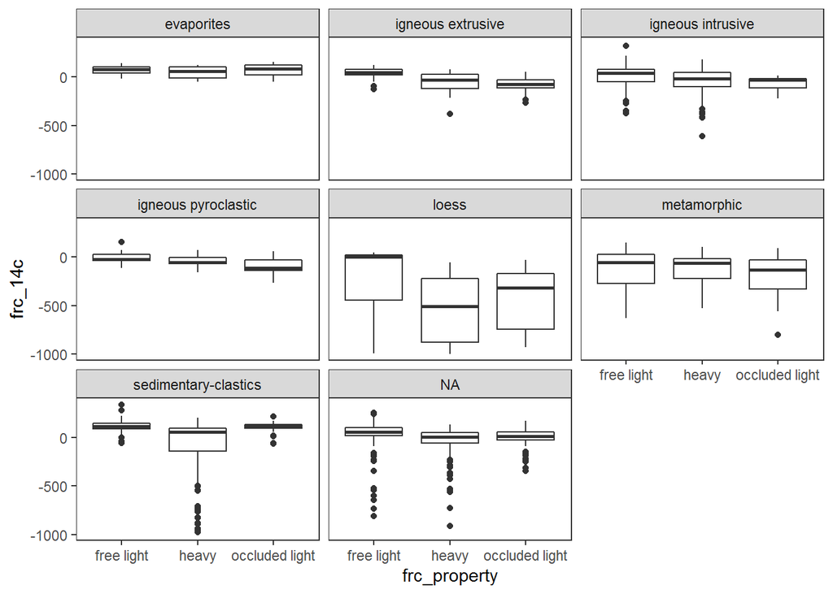

```r
frc_data %>%
  filter(frc_scheme == "Density") %>%
  filter(frc_property != "NA") %>%
  ggplot()+
  geom_boxplot(aes(x=frc_property, y = frc_14c)) +
  theme_bw()+theme(panel.grid.major = element_blank(), panel.grid.minor = element_blank())+
  facet_wrap(~pro_parent_material) #Makes one plot for each parent material
```

#### Is there any temperature dependence in the free light fraction?

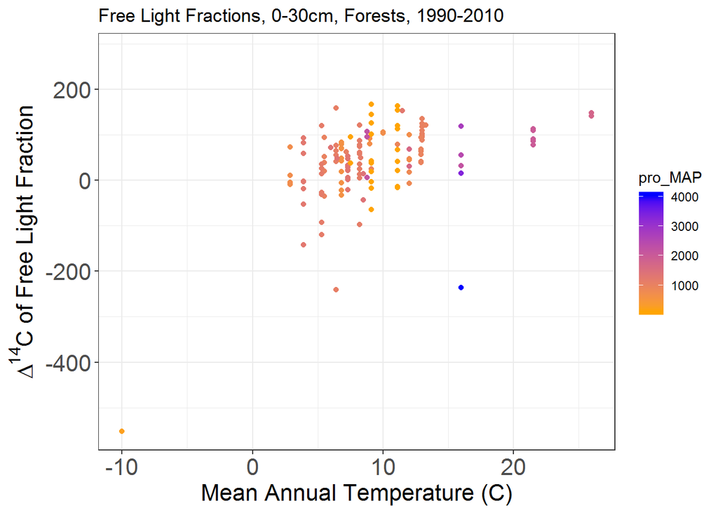

```r
frc_data %>%
  dplyr::filter(lyr_bot <= 30 & lyr_top >=0) %>%
  dplyr::filter(pro_treatment == 'control') %>%
  dplyr::filter(pro_land_cover == "forest") %>%
  dplyr::filter(frc_scheme == "Density") %>%
  dplyr::filter(frc_property == "free light")%>%
  dplyr::filter(lyr_obs_date_y >=1990 & lyr_obs_date_y <= 2010) %>%
  dplyr::filter(is.na(frc_14c) != TRUE) %>%
  #mutate(bin_temp2=cut(pro_MAT_wc, 4)) %>% #Add 4 temperature bins
  ggplot()+
  geom_point(aes(x = pro_MAT, y= frc_14c, color = pro_MAP))+
  theme_bw()+
  xlab("Mean Annual Temperature (C)")+
  ylab(expression(Delta^14 *"C of Free Light Fraction")) +
  ggtitle("Free Light Fractions, 0-30cm, Forests, 1990-2010")+
  scale_color_gradient(low = "orange", high = "blue")+
  theme(axis.text=element_text(size=16),
        axis.title=element_text(size=16))
```

### Mapping ISRaD Data

#### Map all ISRaD layer data, and sites with 14C layer data

Install some helpful mapping packages:

```r
install.packages("maps")
install.packages("ggmap")
library(maps)
library(ggmap)
```

First setup the basemap:

```r
#Maps:
world_map <- map_data("world")

#Creat a base plot with gpplot2
p <- ggplot() + coord_fixed() +
  xlab("") + ylab("")

#Add map to base plot
#Pick color words here: http://sape.inf.usi.ch/quick-reference/ggplot2/colour
base_world_messy <- p + geom_polygon(data=world_map, aes(x=long, y=lat, group=group),
                                     colour="cadetblue4", fill="cadetblue4")

cleanup <- theme(panel.grid.major = element_blank(), panel.grid.minor = element_blank(),
                 panel.background = element_rect(fill = 'white', colour = 'white'),
                 axis.line = element_line(colour = "white"), legend.position="none",
                 axis.ticks=element_blank(), axis.text.x=element_blank(),
                 axis.text.y=element_blank())

base_world <- base_world_messy + cleanup
#base_world #Plots map to screen
```

Plot locations of ISRaD profiles on the map. Yellow points have bulk soil (layer) 14C data. Red points have other data, but do not have bulk soil 14C data.

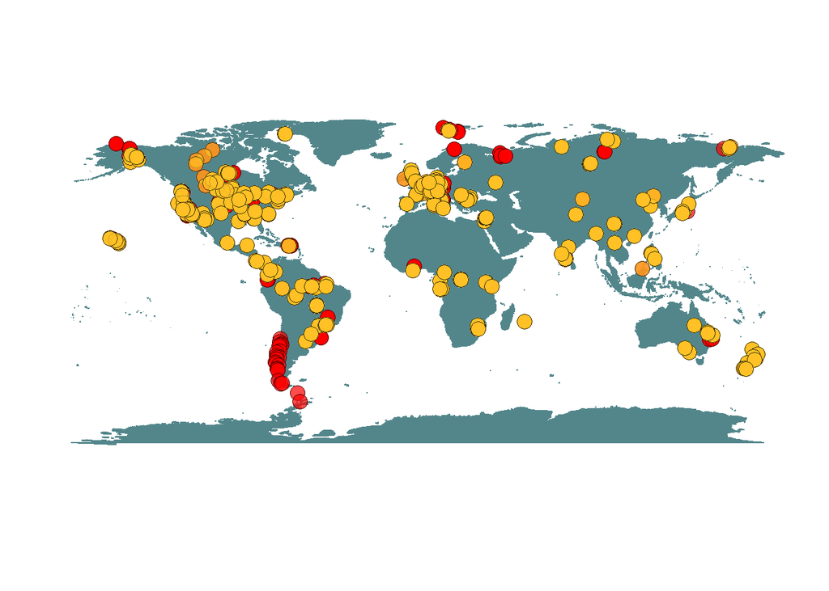

```r
#Filter only data with 14C:
lyr_data_14c <- lyr_data %>%
  dplyr::filter(is.na(lyr_14c) != TRUE)


map_data <-
  base_world +
  geom_point(data=lyr_data, #lyr_all, #put incubation data here to plot points
             aes(x=pro_long, y=pro_lat), colour="black",
             shape = 21, size=4, alpha=I(0.7), fill = "red")+
  geom_point(data=lyr_data_14c, #lyr_all, #put incubation data here to plot points
           aes(x=pro_long, y=pro_lat), colour="black",
           shape = 21, size=4, alpha=I(0.7), fill = "goldenrod1")#+

map_data # Plots map to screen
```

## Compiling your own data offline:

Advanced users may wish to compile thier own data locally in order view it in the context of the larger database. *(note: that this operation is not the same as submitting your data for ingest)*

The `compile` function is used QA/QC and assemble additional datasets (that pass the QA/QC test) into an new list, which can later be merged with `ISRaD_data`.

In order to run `compile` on a set of user specified data entries, the user must create a local folder whose path is specified with `dataset_directory`. This folder must *only contain* the entries to be compiled in .xlsx format. If other files types exist in the directory, `compile` will fail. *(note: entries cannot be open in Excel)*

```r
compiled<-compile(dataset_directory = "~/Directory/to/data/", write_report = T, write_out = T, return="list")
```

The paramter `return` determines format of the object that is returned and should be set to “list” unless the user prefers a flattend version of the database formatted as a single data.frame.

When set to “TRUE”, the parameter `write_out` will trigger the creation of several output files:

| Description | Location | File name |
| --- | --- | --- |
| Report files that identify issues with the files in the dataset_directory | dataset_directory/QAQC | QAQC_*.txt (* corresponds to dataset file names) |
| Flattened database file | dataset_directory/database | ISRaD_flat.csv |
| List structured database file in the same format as template | dataset_directory/database | ISRaD_list.xlsx |
| Log file generated by compile function. Most importatntly, tells you which files passed QAQC. | dataset_directory/database | ISRaD_log.txt |
| Summary statistics for datasets compiled into databaser | dataset_directory/database | ISRaD_summary.csv |
| QAQC check on compiled database. | dataset_directory/database | QAQC_ISRaD_list.txt |

### Merging a user compiled list with `ISRaD_data`

The function `mapply` can be used to merge the user compiled list with `ISRaD_data` as follows:

```r
merged_data<-mapply(rbind, ISRaD_data, compiled, SIMPLIFY=FALSE)
```